# Импорт библиотек

```python
import pandas as pd

from sklearn.preprocessing import StandardScaler
from sklearn.cluster import KMeans, HDBSCAN, Birch
from sklearn.decomposition import PCA
from sklearn.metrics import silhouette_score, davies_bouldin_score, calinski_harabasz_score

from matplotlib import pyplot as plt
import seaborn as sns
```

# Импорт данных

```python
df = pd.read_csv('data/Air_Quality.csv')

df.head(3)
```

|  | Date | City | CO | NO2 | SO2 | O3 | PM2.5 | PM10 | AQI |
| --- | --- | --- | --- | --- | --- | --- | --- | --- | --- |
| 0 | 2025-01-01 00:00:00+00:00 | Brasilia | 325.0 | 21.1 | 2.5 | 35.0 | 15.4 | 15.6 | 20.483337 |
| 1 | 2025-01-01 01:00:00+00:00 | Brasilia | 369.0 | 20.8 | 2.7 | 35.0 | 15.1 | 15.3 | 20.425000 |
| 2 | 2025-01-01 02:00:00+00:00 | Brasilia | 419.0 | 20.4 | 3.0 | 34.0 | 15.6 | 15.8 | 20.333332 |

Для кластеризации уберем все лишние признаки, оставим только числовые. Их отмасштабируем для лучшей производительности.

```python
X = df.select_dtypes(include='number')

scaler = StandardScaler()
X = pd.DataFrame(scaler.fit_transform(X), columns=X.columns)

X.sample(3)
```

|  | CO | NO2 | SO2 | O3 | PM2.5 | PM10 | AQI |
| --- | --- | --- | --- | --- | --- | --- | --- |
| 2888 | -0.539524 | -0.989971 | -0.580177 | -0.439789 | -0.832623 | -0.654974 | -0.951463 |
| 48466 | -0.328533 | 1.028280 | -0.418850 | -1.067395 | -0.638185 | -0.549216 | -0.863514 |
| 25523 | 0.706008 | 1.105905 | 0.537012 | 1.243338 | 1.533045 | 0.709031 | 1.529434 |

# Оптимальное количество кластеров

Для определения оптимального количества кластеров, тк не все алгоритмы их определяют, используем метод локтя.

Для реализации метода берем KMeans, тут нам важно просто выбить критерий, ну и определить кол-во кластеров. Для других моделей (AgglomerativeClustering, BIRCH и тд) используем то же кол-во.

[Все придумали за нас](https://stackoverflow.com/questions/41540751/sklearn-kmeans-equivalent-of-elbow-method)

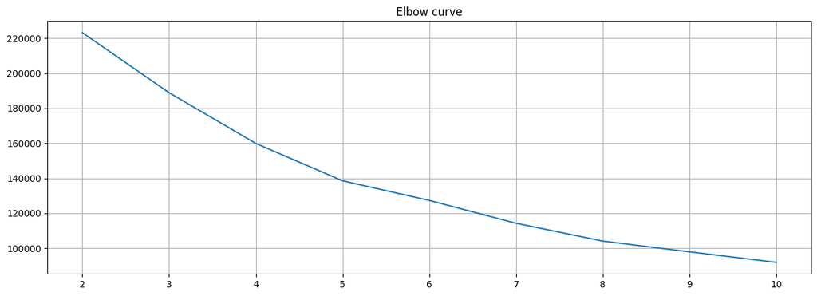

```python
distorsions = []
for k in range(2, 11):
    kmeans = KMeans(n_clusters=k)
    kmeans.fit(X)
    distorsions.append(kmeans.inertia_)

fig = plt.figure(figsize=(15, 5))
plt.plot(range(2, 11), distorsions)
plt.grid(True)
plt.title('Elbow curve');
```

Данные не очень хорошо кластеризуются. Такое поведение вполне возможно на чемпионате. Поэтому важно правильно интерпретировать и аргументировать эти результаты.

> Исходя из графика, мы видим, что внутрекластерное расстояние постепенно падает, но главное искривление происходит на 5 кластерах.

n_clusters=5

# Модели кластеризации

[Документация](https://scikit-learn.org/stable/modules/clustering.html)

## KMeans

```python
kmeans_df = df.copy()

kmeans = KMeans(n_clusters=5)
kmeans.fit(X)
kmeans_df['label'] = kmeans.predict(X)
```

## HDBSCAN

Тут количество кластеров указывать не нужно.

```python
hdbcan_df = df.copy()

hdbcan = HDBSCAN()
hdbcan_df['label'] = hdbcan.fit_predict(X)
```

## BIRCH

```python
birch_df = df.copy()

birch = Birch(n_clusters=5)
birch.fit(X)
birch_df['label'] = birch.predict(X)
```

## Анализ кластеризации и дисбаланс классов

Очевидно, что идеальную кластеризацию провести в этими данными тяжело. Некоторые модели могут очень плохо отработать. Поэтому мы кластеризуем тремя моделями.

```python
kmeans_df['label'].value_counts()
```

```
label
1    24929
4     9575
2     9510
3     4744
0     3802
Name: count, dtype: int64
```

```python
hdbcan_df['label'].value_counts()
```

```
label
 0    52541
-1       14
 1        5
Name: count, dtype: int64
```

HDBSCAN не смог найти закономерности в данных и разделить их на кластеры.

```python
birch_df['label'].value_counts()
```

```
label
2    46219
4     2334
1     1863
3     1333
0      811
Name: count, dtype: int64
```

# Визуализация кластеров

Для визуализации кластеров используем методы понижения размерности - PCA (метод главных компонент)

```python
pca = PCA(n_components=2)
X_cpa = pca.fit_transform(X)
df_pca = pd.DataFrame(X_cpa, columns=['x', 'y'])
df_pca
df_pca.head(3)
```

|  | x | y |
| --- | --- | --- |
| 0 | -0.676445 | -0.949220 |
| 1 | -0.582084 | -0.995249 |
| 2 | -0.440454 | -1.061845 |

Функция scatterplot из seaborn может долго работать на большом наборе данных. Для ускорения работы мы можем уменьшить количество данных на графике, это не сильно повлияет на саму визуализацию.

```python
sample_indx = df_pca.sample(10000).index
```

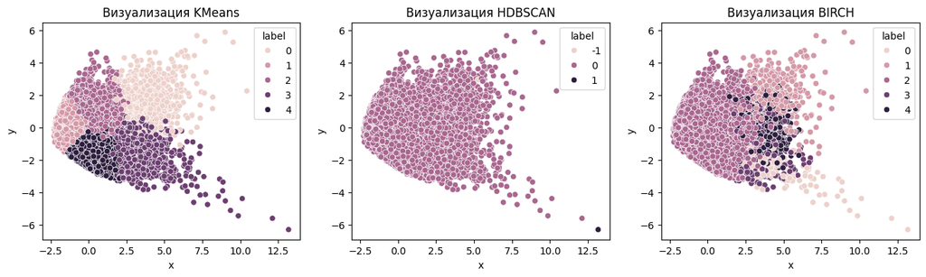

```python
fig, axs = plt.subplots(1, 3, figsize=(16, 4))

sns.scatterplot(df_pca.iloc[sample_indx],
                x='x', y='y',
                hue=kmeans_df.iloc[sample_indx]['label'],
                ax=axs[0])
axs[0].set_title('Визуализация KMeans')


sns.scatterplot(df_pca.iloc[sample_indx],
                x='x', y='y',
                hue=hdbcan_df.iloc[sample_indx]['label'],
                ax=axs[1])
axs[1].set_title('Визуализация HDBSCAN')


sns.scatterplot(df_pca.iloc[sample_indx],
                x='x', y='y',
                hue=birch_df.iloc[sample_indx]['label'],
                ax=axs[2])
axs[2].set_title('Визуализация BIRCH');
```

# Метрики качества кластеризации

## Silhouette Score

Чем выше метрика, тем лучше.

```python
print(f'''
Индекс Silhouette Score
KMeans: {silhouette_score(X, kmeans_df['label']):.2f}
HDBSCAN: {silhouette_score(X, hdbcan_df['label']):.2f}
BIRCH: {silhouette_score(X, birch_df['label']):.2f}
''')
```

```
Индекс Silhouette Score
KMeans: 0.33
HDBSCAN: 0.75
BIRCH: 0.44
```

## Calinski–Harabasz Index

Чем больше, тем лучше.

```python
print(f'''
Индекс Calinski–Harabasz
KMeans: {calinski_harabasz_score(X, kmeans_df['label']):.2f}
HDBSCAN: {calinski_harabasz_score(X, hdbcan_df['label']):.2f}
BIRCH: {calinski_harabasz_score(X, birch_df['label']):.2f}
''')
```

```
Индекс Calinski–Harabasz
KMeans: 21751.38
HDBSCAN: 250.64
BIRCH: 9078.85
```

## Davies–Bouldin Index

Чем меньше, тем лучше

```python
print(f'''
Индекс Дэвиcа-Болдуина
KMeans: {davies_bouldin_score(X, kmeans_df['label']):.2f}
HDBSCAN: {davies_bouldin_score(X, hdbcan_df['label']):.2f}
BIRCH: {davies_bouldin_score(X, birch_df['label']):.2f}
''')
```

```
Индекс Дэвиcа-Болдуина
KMeans: 1.25
HDBSCAN: 0.89
BIRCH: 1.45
```

Тут возможны неоднозначные ситуации как сейчас.

В таком случае, лучше написать:

> Исходя из анализа дисбаланса классов, визулизации и оценки метрик, лучшим алгоритмом стал KMeans. Эта модель показала лучшее распределение данных...

# Обзор кластеров

Для модели KMeans проведем обзор кластеров. Важно использовать изначальные данные, а не отмасштабированные.

```python
df[['CO',	'NO2', 'SO2', 'O3', 'PM2.5', 'PM10', 'AQI']].groupby(kmeans_df['label']).mean()
```

| label | CO | NO2 | SO2 | O3 | PM2.5 | PM10 | AQI |
| --- | --- | --- | --- | --- | --- | --- | --- |
| 0 | 381.128353 | 35.199395 | 23.179537 | 100.104419 | 51.445318 | 128.743267 | 89.810336 |
| 1 | 164.839023 | 11.379361 | 2.965634 | 62.331782 | 6.477837 | 8.249144 | 26.308985 |
| 2 | 244.968875 | 18.860284 | 26.919863 | 102.237645 | 19.797645 | 32.584637 | 56.817031 |
| 3 | 486.352656 | 59.870152 | 57.211425 | 40.248103 | 39.817496 | 59.567770 | 66.908838 |
| 4 | 281.581514 | 40.457034 | 12.994350 | 30.082089 | 17.987394 | 22.262830 | 32.620200 |

На основе этих данных можно описать каждый кластер.